# Bivariate analyser III – lineær regression (OLS) fortsat

Metode 1 F25 #11

Søren Damsbo-Svendsen

30. april 2025

## Temaer

- Lineær regression
  - OLS
  - Prediktion (forudsigelse)
  - Multipel regression
  - Kausalitet og kausaldiagrammer
  - Confounders og kontrolvariable
  - Antagelser, udvidelser, regressionstabeller mv.

## Hovedpointer

- **Lineær regression** er en ekstremt alsidig metode
  - nok den vigtigste metode til analyse i kvant. samfundsvidenskab
  - kan bruges til *sammenhængsanalyse* med mange variabeltyper
  - kan bruges til *prediktion* (forudsigelse)
  - kan bruges til ‘*multivariat*’ sammenhængsanalyse, herunder **kausal inferens**
  - krævende antagelser: især at alle *confounders* er inkluderet i modellen

## Plan for forelæsningen

1. Recap — 10 ting vi lærte om OLS i sidste uge
2. Et enkelt eksempel
3. Forudsigelse
4. Multipel regression
   - kausalitet
   - kausaldiagrammer
   - confounders og kontrolvariable
5. Vigtige noter om OLS
6. Eksempel fra valgundersøgelsen

# Recap — 10 ting vi lærte om OLS i sidste uge

### (1) at “OLS” (Ordinary Least Squares) refererer til, at de rette linjer placeres, så *summen af residualerne^2* er mindst mulig

**Kode**

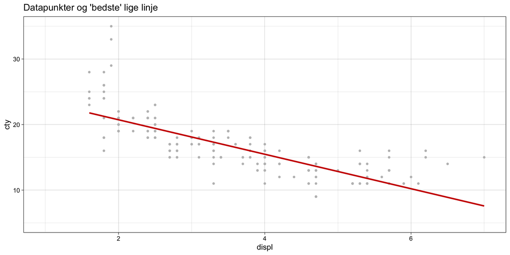

```r
m <- lm(cty ~ displ, data = mpg)
mpg$pred <- predict(m)
mpg$resid <- resid(m)

p_ols1 <- mpg |>
  ggplot() +
  aes(x = displ, y = cty) +
  coord_cartesian(xlim = c(1, 7), ylim = c(5, 35)) +
  theme_linedraw() +
  geom_point(size = 1, color = "grey") +
  geom_smooth(method = "lm", se = FALSE, color = "red3")

p_ols1 + labs(title = "Datapunkter og 'bedste' lige linje")
```

### (1) at “OLS” (Ordinary Least Squares) refererer til, at de rette linjer placeres, så *summen af residualerne^2* er mindst mulig

**Kode**

```r
p_ols1 +
  geom_linerange(aes(xmin = displ, xmax = displ, ymin = pred, ymax = cty), alpha = .25, linewidth = 1, data = filter(mpg, resid > 0)) +
  geom_linerange(aes(xmin = displ, xmax = displ, ymin = cty, ymax = pred), alpha = .25, linewidth = 1, data = filter(mpg, resid < 0)) +
  geom_smooth(method = "lm", se = FALSE, color = "red3") +
  labs(title = "Residualer (uforklaret varians)")
```

[figure not shown]

### (1) at “OLS” (Ordinary Least Squares) refererer til, at de rette linjer placeres, så *summen af residualerne^2* er mindst mulig

**Kode**

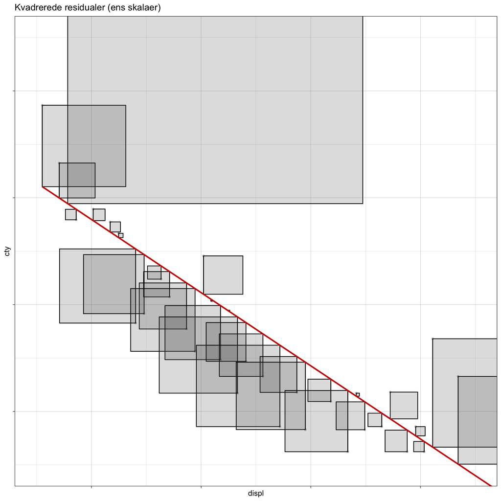

```r
mpg_simpel <- mpg |>
  mutate(displ = scale(displ)[,1],
         cty = scale(cty)[,1]) |>
  group_by(displ) |>
  summarise(displ = mean(displ),
            cty = mean(cty)) |>
  ungroup()

m <- lm(cty ~ displ, data = mpg_simpel)
mpg_simpel$pred <- predict(m)
mpg_simpel$resid <- resid(m)

mpg_simpel |>
  ggplot() +
  aes(x = displ, y = cty) +
  theme_linedraw() +
  geom_point(size = 1, color = "grey") +
  geom_linerange(aes(xmin = displ, xmax = displ, ymin = pred, ymax = cty), linewidth = .5, data = filter(mpg_simpel, resid > 0)) +
  geom_linerange(aes(xmin = displ, xmax = displ, ymin = cty, ymax = pred), linewidth = .5, data = filter(mpg_simpel, resid < 0)) +
  geom_rect(aes(xmin = displ + resid, xmax = displ, ymin = pred, ymax = cty), alpha = .2, linewidth = .5, color = "black") +
  geom_smooth(method = "lm", se = FALSE, color = "red3") +
  coord_cartesian(xlim = c(-1.5, 2.5), ylim = c(-1.5,2.5)) +
  theme(axis.text = element_blank()) +
  labs(title = "Kvadrerede residualer (ens skalaer)")
```

### (2) at lineær regression udregner *betingede gennemsnit* – eller noget der minder meget derom: rette linjer<sup>1</sup>

**Kode**

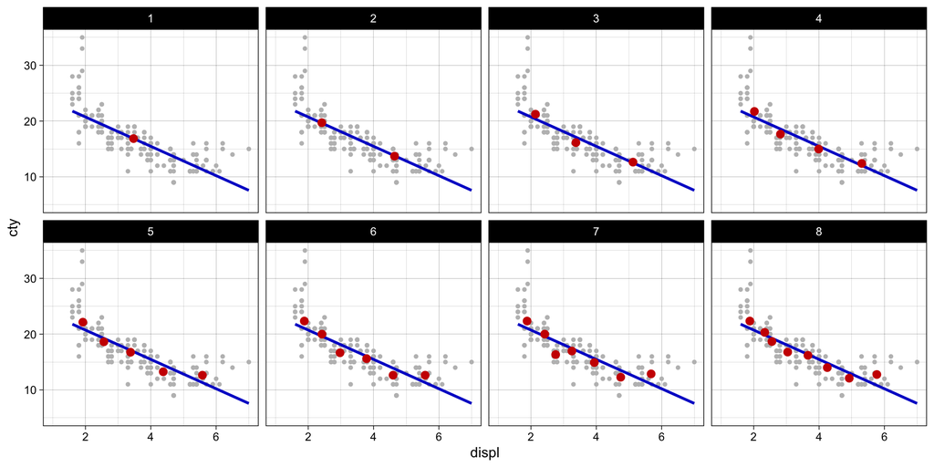

```r
# 1-8 betingede gennemsnit
bgns <- map(1:8, ~mpg |>
              mutate(displ_kat = cut_number(displ, .)) |>
              group_by(displ_kat) |>
              summarise(displ = mean(displ),
                        cty = mean(cty),
                        n = n()) |>
              ungroup()) |>
  bind_rows(.id = "n_grupper") |>
  mutate(n_grupper = as.integer(n_grupper))

# base plot (x = displ, y = cty) med facets
p1 <- mpg |>
  ggplot() +
  aes(x = displ, y = cty) +
  coord_cartesian(xlim = c(1, 7), ylim = c(5, 35)) +
  theme_linedraw() +
  geom_point(size = 1, color = "grey") +
  facet_wrap(~ n_grupper, nrow = 2)

p1 + geom_smooth(method = "lm", data = mpg, se = FALSE, color = "blue3") + # "lm": lineær model
  geom_point(size = 2.5, color = "red3", data = bgns)
```

[^1]: Smarte fordi de beskriver X-Y-sammenhængen med blot to tal: *hældningen* (vigtigst!) og konstanten/skæringspunktet med Y.

### (3) at sammenhængen mellem to intervalskalerede variable kan beskrives med hældningen – som estimeres med OLS

**Kode**

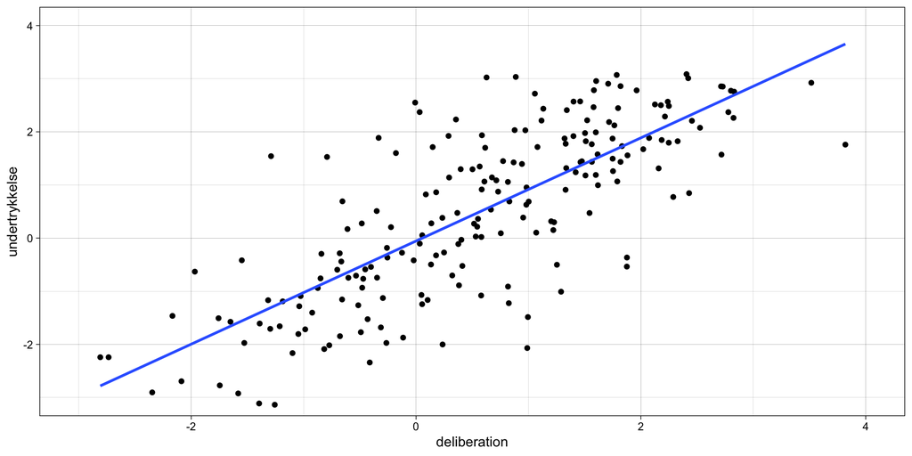

```r
vdem <- read_csv(here::here("Data/V-Dem-CY-Core-v15_csv/V-Dem-CY-Core-v15.csv")) |>
  select(-contains("_code"), -contains("_sd")) |>
  group_by(country_name) |>
  arrange(year) |>
  slice(max(row_number())) |>
  ungroup()

vdem_select <- vdem |>
  select(country_name,
         deliberation = v2dlengage,
         undertrykkelse = v2csreprss,
         journalister = v2meharjrn) |>
  # kun lande med observationer på alle tre variable
  drop_na()

vdem_select |>
  ggplot() +
  aes(x = deliberation, undertrykkelse) +
  geom_point() +
  geom_smooth(method = "lm", se = FALSE) + # lineær linje
  theme_linedraw() +
  coord_cartesian(xlim = c(-3, 4), ylim = c(-3, 4))
```

### (3) at sammenhængen mellem to intervalskalerede variable kan beskrives med hældningen – som estimeres med OLS

**Kode**

```r
# OLS-regressionskoefficienter
lm(undertrykkelse ~ deliberation, data = vdem_select) |>
  summary()
```

```
Call:
lm(formula = undertrykkelse ~ deliberation, data = vdem_select)

Residuals:
     Min       1Q   Median       3Q      Max
-2.97413 -0.49625 -0.04753  0.58575  2.84883

Coefficients:
             Estimate Std. Error t value            Pr(>|t|)
(Intercept)  -0.05478    0.07966  -0.688               0.492
deliberation  0.97058    0.05693  17.048 <0.0000000000000002 ***
---
Signif. codes:  0 '***' 0.001 '**' 0.01 '*' 0.05 '.' 0.1 ' ' 1

Residual standard error: 1.026 on 198 degrees of freedom
Multiple R-squared:  0.5948,    Adjusted R-squared:  0.5928
F-statistic: 290.6 on 1 and 198 DF,  p-value: < 0.00000000000000022
```

### (4) at vi primært er interesseret i OLS-regressionskoefficienterne, sekundært i deres statistiske signifikans (tertiært i andre outputs)

**Kode**

```r
# OLS-regressionskoefficienter
lm(undertrykkelse ~ deliberation, data = vdem_select) |>
  summary()
```

```
Call:
lm(formula = undertrykkelse ~ deliberation, data = vdem_select)

Residuals:
     Min       1Q   Median       3Q      Max
-2.97413 -0.49625 -0.04753  0.58575  2.84883

Coefficients:
             Estimate Std. Error t value            Pr(>|t|)
(Intercept)  -0.05478    0.07966  -0.688               0.492
deliberation  0.97058    0.05693  17.048 <0.0000000000000002 ***
---
Signif. codes:  0 '***' 0.001 '**' 0.01 '*' 0.05 '.' 0.1 ' ' 1

Residual standard error: 1.026 on 198 degrees of freedom
Multiple R-squared:  0.5948,    Adjusted R-squared:  0.5928
F-statistic: 290.6 on 1 and 198 DF,  p-value: < 0.00000000000000022
```

### (5) at den afhængige variabel, Y, altid er intervalskaleret, mens de(n) uafhængige variable, X, kan have alle måleniveauer – fortolkningen varierer blot lidt

- **intervalskaleret** X: hvor meget højere/lavere er Y,  
  *når X vokser med +1*
- **binært** X: hvor meget højere/lavere er Y,  
  *når X = 1 sammenlignet med X = 0*
- **kategorisk** X: hvor meget højere/lavere er Y,  
  *når X = b, c eller d sammenlignet med referencekategorien a*

### (6) at OLS-modeller med kategoriske X-variable giver os *forskellene* i betingede gennemsnit sammenlignet med referencekategorien

**Kode**

```r
vdem_select2 <- vdem |>
  transmute(country_name,
            histname,
            # binær
            navn_democratic = if_else(str_detect(tolower(histname), "democratic"), 1, 0, 0), # er der "democratic" i navnet (ja/nej)?
            # kategorisk
            navn_type = case_when(str_detect(tolower(histname), "republic") ~ "republic", # er der "republic" i navnet?
                                  str_detect(tolower(histname), "kingdom") ~ "kingdom", # er der "kingdom" i navnet?
                                  .default = "andet"), # ellers -> "andet"
            deliberation = v2dlengage,
            undertrykkelse = v2csreprss,
            journalister = v2meharjrn) |>
  # kun lande med observationer på alle tre variable
  drop_na()

lm(undertrykkelse ~ navn_type, data = vdem_select2) |>
  summary()
```

```
Call:
lm(formula = undertrykkelse ~ navn_type, data = vdem_select2)

Residuals:
    Min      1Q  Median      3Q     Max
-3.7404 -1.3074  0.2176  1.3146  2.6806

Coefficients:
                  Estimate Std. Error t value Pr(>|t|)
(Intercept)        0.38941    0.22940   1.697   0.0912 .
navn_typekingdom   0.02894    0.42610   0.068   0.9459
navn_typerepublic  0.21503    0.26976   0.797   0.4264
---
Signif. codes:  0 '***' 0.001 '**' 0.01 '*' 0.05 '.' 0.1 ' ' 1

Residual standard error: 1.606 on 194 degrees of freedom
Multiple R-squared:  0.003836,  Adjusted R-squared:  -0.006434
F-statistic: 0.3735 on 2 and 194 DF,  p-value: 0.6888
```

### (7) at konstanten viser det betingede gennemsnit for X = 0 (referencekategori) – uanset hvor mange/hvilke X

**Kode**

```r
lm(undertrykkelse ~ navn_democratic, data = vdem_select2) |>
  summary()
```

```
Call:
lm(formula = undertrykkelse ~ navn_democratic, data = vdem_select2)

Residuals:
    Min      1Q  Median      3Q     Max
-3.6951 -1.2621  0.2629  1.3139  2.6425

Coefficients:
                Estimate Std. Error t value   Pr(>|t|)
(Intercept)       0.5591     0.1174   4.763 0.00000372 ***
navn_democratic  -0.4836     0.4968  -0.974      0.331
---
Signif. codes:  0 '***' 0.001 '**' 0.01 '*' 0.05 '.' 0.1 ' ' 1

Residual standard error: 1.601 on 195 degrees of freedom
Multiple R-squared:  0.004837,  Adjusted R-squared:  -0.0002666
F-statistic: 0.9478 on 1 and 195 DF,  p-value: 0.3315
```

### (8) at konstanten viser det samlede gennemsnit, hvis der intet X er

**Kode**

```r
# # gennemsnit
# mean(vdem_select$undertrykkelse)

# univariat lineær regression -> konstant (Intercept)
lm(undertrykkelse ~ 1, data = vdem_select) |>
  summary()
```

```
Call:
lm(formula = undertrykkelse ~ 1, data = vdem_select)

Residuals:
    Min      1Q  Median      3Q     Max
-3.6421 -1.2558  0.1849  1.3227  2.5789

Coefficients:
            Estimate Std. Error t value  Pr(>|t|)
(Intercept)   0.5061     0.1137   4.452 0.0000142 ***
---
Signif. codes:  0 '***' 0.001 '**' 0.01 '*' 0.05 '.' 0.1 ' ' 1

Residual standard error: 1.608 on 199 degrees of freedom
```

### (9) at R^2 er et mål for andelen af variansen af Y, som kan forklares med X<sup>1</sup>

**Kode**

```r
# OLS-regressionskoefficienter
lm(undertrykkelse ~ deliberation, data = vdem_select) |>
  summary()
```

```
Call:
lm(formula = undertrykkelse ~ deliberation, data = vdem_select)

Residuals:
     Min       1Q   Median       3Q      Max
-2.97413 -0.49625 -0.04753  0.58575  2.84883

Coefficients:
             Estimate Std. Error t value            Pr(>|t|)
(Intercept)  -0.05478    0.07966  -0.688               0.492
deliberation  0.97058    0.05693  17.048 <0.0000000000000002 ***
---
Signif. codes:  0 '***' 0.001 '**' 0.01 '*' 0.05 '.' 0.1 ' ' 1

Residual standard error: 1.026 on 198 degrees of freedom
Multiple R-squared:  0.5948,    Adjusted R-squared:  0.5928
F-statistic: 290.6 on 1 and 198 DF,  p-value: < 0.00000000000000022
```

[^2]: $R^2$ er i øvrigt bare *Pearsons r* i anden (kun for bivariate regressionsmodeller)

### (10) at OLS-koefficienterne ikke er sensitive overfor *tilfældig støj* rundt om tendensen – sammenhængens ‘uordentlighed’ (modsat Pearsons r)

**Kode**

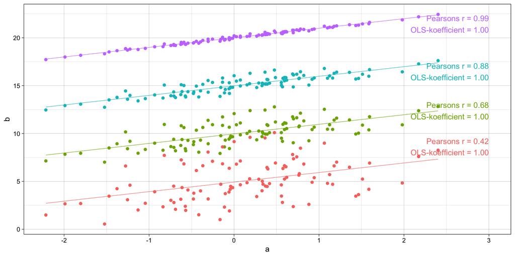

```r
set.seed(1)
df <- tibble(a = rnorm(100),
             b_noise = rnorm(100),
             b1 = 5 + a * 1 + b_noise * 2,
             b2 = 10 + a * 1 + b_noise * 1,
             b3 = 15 + a * 1 + b_noise * .5,
             b4 = 20 + a * 1 + b_noise * .1,
) |>
  pivot_longer(c(b1, b2, b3, b4), names_to = "v", values_to = "b")

df_calc <- df |>
  group_by(v) |>
  mutate(r = format(cor(a, b), digits = 2, nsmall = 2),
         c = format(pluck(coef(lm(b ~ a)), 2), digits = 2, nsmall = 2)) |>
  ungroup() |>
  group_by(v, r, c) |>
  summarise(a = 3,
            b = quantile(b, probs = .95))

df |>
  ggplot() +
  aes(x = a, y = b, color = v) +
  geom_point() +
  geom_smooth(method = "lm", se = FALSE, linewidth = .25) +
  geom_text(aes(label = paste0("Pearsons r = ", r, "\n", "OLS-koefficient = ", c)), hjust = 1, data = df_calc) +
  theme_linedraw() +
  guides(color = "none")
```

# Lineær regression – simpelt eksempel

## Lineær regression – simpelt eksempel

- Formålet er at estimere sammenhængen mellem nogle uafhængige variable (X) og en afhængig variabel (Y)
  - OLS-modellen estimerer betingede gennemsnit af Y eller rette linjer for hvert X
- Modellen forudsiger alle enheders Y-værdi med fejl (residualerne)
  - minimerer fejlen (kvadraterne)
- OLS opsummerer/beskriver sammenhænge i data med regressionskoefficienter mv.
- OLS udregner forudsagte Y-værdier og prektionsfejl (residualer) for alle enheder
- $y_i = \alpha + \beta_1 X_1 + \beta_2 X_2 + ... + \epsilon_i$

## Data

**Kode**

```r
set.seed(2)

# simulerede data
legedata <- tibble(
  # x1: intervalskaleret
  x1 = rnorm(n = 30, mean = 5, sd = 2),
  # x2: binær
  x2 = sample(c(0, 1), size = 30, replace = TRUE, prob = c(.5, .5)),
  # x3: kategorisk
  x3 = sample(c("A", "B", "C"), size = 30, replace = TRUE, prob = c(.15, .6, .25)),
  # y påvirkes af alle tre X'er
  y = 1 * x1 + 7.5 * x2 + case_when(x3 == "A" ~ 2, x3 == "B" ~ -3, x3 == "C" ~ 3) + rnorm(30))

kable(head(legedata, 10), digits = 2)
```

## Data

| x1 | x2 | x3 | y |
| --- | --- | --- | --- |
| 3.21 | 0 | A | 3.42 |
| 5.37 | 0 | B | 4.40 |
| 8.18 | 0 | B | 4.47 |
| 2.74 | 1 | B | 7.40 |
| 4.84 | 0 | B | 2.35 |
| 5.26 | 1 | B | 8.94 |
| 6.42 | 1 | B | 8.92 |
| 4.52 | 1 | B | 8.54 |
| 8.97 | 1 | B | 13.55 |
| 4.72 | 1 | B | 8.33 |

## Data – deskriptiv statistik

```r
library(modelsummary)

datasummary_skim(legedata)
```

|  | Unique (#) | Missing (%) | Mean | SD | Min | Median | Max |  |
| --- | --- | --- | --- | --- | --- | --- | --- | --- |
| x1 | 30 | 0 | 5.5 | 2.3 | 0.1 | 5.5 | 9.2 |  |
| x2 | 2 | 0 | 0.6 | 0.5 | 0.0 | 1.0 | 1.0 |  |
| y | 30 | 0 | 8.6 | 4.8 | −3.5 | 8.7 | 17.6 |  |

```r
datasummary_skim(legedata, "categorical")
```

| x3 | N | % |
| --- | --- | --- |
| A | 5 | 16.7 |
| B | 21 | 70.0 |
| C | 4 | 13.3 |

## Univariat regressionsmodel

**Kode**

```r
lm(y ~ 1, data = legedata) |>
  summary()
```

```
Call:
lm(formula = y ~ 1, data = legedata)

Residuals:
     Min       1Q   Median       3Q      Max
-12.1241  -4.0107   0.1344   3.8753   8.9659

Coefficients:
            Estimate Std. Error t value        Pr(>|t|)
(Intercept)   8.5948     0.8721   9.855 0.0000000000918 ***
---
Signif. codes:  0 '***' 0.001 '**' 0.01 '*' 0.05 '.' 0.1 ' ' 1

Residual standard error: 4.777 on 29 degrees of freedom
```

## Bivariat regressionsmodel (X1)

**Kode**

```r
lm(y ~ x1, data = legedata) |>
  summary()
```

```
Call:
lm(formula = y ~ x1, data = legedata)

Residuals:
    Min      1Q  Median      3Q     Max
-7.5970 -1.8039  0.5612  1.8220  8.1058

Coefficients:
            Estimate Std. Error t value Pr(>|t|)
(Intercept)   2.4739     1.9013   1.301   0.2038
x1            1.1216     0.3209   3.495   0.0016 **
---
Signif. codes:  0 '***' 0.001 '**' 0.01 '*' 0.05 '.' 0.1 ' ' 1

Residual standard error: 4.056 on 28 degrees of freedom
Multiple R-squared:  0.3038,    Adjusted R-squared:  0.2789
F-statistic: 12.22 on 1 and 28 DF,  p-value: 0.001595
```

## Bivariat regressionsmodel (X2)

**Kode**

```r
lm(y ~ x2, data = legedata) |>
  summary()
```

```
Call:
lm(formula = y ~ x2, data = legedata)

Residuals:
    Min      1Q  Median      3Q     Max
-7.1408 -2.1343  0.4356  1.7493  6.0809

Coefficients:
            Estimate Std. Error t value     Pr(>|t|)
(Intercept)   3.6116     0.8649   4.176     0.000262 ***
x2            7.8683     1.0868   7.240 0.0000000701 ***
---
Signif. codes:  0 '***' 0.001 '**' 0.01 '*' 0.05 '.' 0.1 ' ' 1

Residual standard error: 2.869 on 28 degrees of freedom
Multiple R-squared:  0.6518,    Adjusted R-squared:  0.6394
F-statistic: 52.41 on 1 and 28 DF,  p-value: 0.00000007009
```

## Bivariat regressionsmodel (X3)

**Kode**

```r
lm(y ~ x3, data = legedata) |>
  summary()
```

```
Call:
lm(formula = y ~ x3, data = legedata)

Residuals:
     Min       1Q   Median       3Q      Max
-11.7109  -3.7628   0.5476   3.9371   7.5507

Coefficients:
            Estimate Std. Error t value  Pr(>|t|)
(Intercept)   10.010      2.190   4.571 0.0000965 ***
x3B           -1.828      2.437  -0.750      0.46
x3C           -1.015      3.285  -0.309      0.76
---
Signif. codes:  0 '***' 0.001 '**' 0.01 '*' 0.05 '.' 0.1 ' ' 1

Residual standard error: 4.897 on 27 degrees of freedom
Multiple R-squared:  0.02152,   Adjusted R-squared:  -0.05096
F-statistic: 0.2969 on 2 and 27 DF,  p-value: 0.7455
```

## Bivariat regressionsmodel (X3) – ny referencekategori

**Kode**

```r
legedata |>
  mutate(x3 = factor(x3, levels = c("B", "A", "C"))) |>
  lm(y ~ x3, data = _) |>
  summary()
```

```
Call:
lm(formula = y ~ x3, data = mutate(legedata, x3 = factor(x3,
    levels = c("B", "A", "C"))))

Residuals:
     Min       1Q   Median       3Q      Max
-11.7109  -3.7628   0.5476   3.9371   7.5507

Coefficients:
            Estimate Std. Error t value    Pr(>|t|)
(Intercept)   8.1816     1.0686   7.656 0.000000031 ***
x3A           1.8284     2.4368   0.750       0.460
x3C           0.8135     2.6715   0.305       0.763
---
Signif. codes:  0 '***' 0.001 '**' 0.01 '*' 0.05 '.' 0.1 ' ' 1

Residual standard error: 4.897 on 27 degrees of freedom
Multiple R-squared:  0.02152,   Adjusted R-squared:  -0.05096
F-statistic: 0.2969 on 2 and 27 DF,  p-value: 0.7455
```

## Forudsigelse af Y med lineær regression

- Prediktion af Y-værdier for alle enheder i datasættet pba. X
- God måde at tænke på OLS-modeller
  - når sigtet ikke eksplicit er kausal inferens
  - vi forsøger at *forudsige Y* så godt som muligt ud fra *X*
- Vi kan kalde vores X’er for “prediktorer” (forudsigere)
- OLS-modeller vil altid forsøge at optimere forudsigelsen af Y
  - også selvom *forudsigelse* ikke eksplicit er målet
  - fx hvis fokus er på *sammenhænge* (evt. kausale), ikke på *Y*
- Vi prøver at anlægge det perspektiv →

## Forudsigelse af Y med lineær regression

- Vi prøver at forudsige Y ud fra x1 og x2
  - gemmer forudsigelserne
  - gemmer residualerne (fejlene)

**Kode**

```r
# lav en lineær regressionsmodel med x1 og x2
m <- lm(y ~ x1 + x2, data = legedata)

# gem modellens forudsigelser (y_forudsagt) + residualer (y_residualer) i det orig. datasæt
legedata_pred <- legedata |>
  select(-x3) |>
  mutate(y_forudsagt = predict(m),
         y_residual = residuals(m)) |>
  # sorter efter residualerne ('fejlgæt')
  arrange(y_residual)

# vis datasættets første og sidste fem rækker
legedata_pred |>
  mutate(nr = row_number(), .before = 1) |>
  slice(c(1:7, 28:30)) |>
  kable(digits = 1) |>
  kable_styling(font_size = 24)
```

## Forudsigelse af Y med lineær regression

| nr | x1 | x2 | y | y_forudsagt | y_residual |
| --- | --- | --- | --- | --- | --- |
| 1 | 0.4 | 0 | -3.5 | 1.2 | -4.7 |
| 2 | 5.9 | 0 | 1.5 | 4.5 | -3.1 |
| 3 | 6.4 | 1 | 8.9 | 11.7 | -2.8 |
| 4 | 4.7 | 1 | 8.3 | 10.6 | -2.3 |
| 5 | 3.8 | 1 | 8.0 | 10.1 | -2.1 |
| 6 | 5.3 | 1 | 8.9 | 11.0 | -2.0 |
| 7 | 2.7 | 1 | 7.4 | 9.4 | -2.0 |
| 28 | 0.1 | 0 | 4.9 | 1.0 | 3.9 |
| 29 | 2.9 | 1 | 13.9 | 9.5 | 4.3 |
| 30 | 6.8 | 1 | 17.6 | 11.9 | 5.7 |

## Forudsigelse af Y med lineær regression

- Vi prøver også at forudsige Y UDEN x1 og x2
  - gemmer forudsigelserne (gennemsnittet)
  - gemmer residualerne (fejlene)

**Kode**

```r
# univariat model / nulmodel (gennemsnit)
m0 <- lm(y ~ 1, data = legedata_pred)

# gem den univariate models forudsigelser (y_forudsagt0) + residualer (y_residualer0) i det orig. datasæt
legedata_pred2 <- legedata_pred |>
  mutate(y_forudsagt0 = predict(m0),
         y_residual0 = residuals(m0)) |>
  # hvor meget reducerer modellen (x1, x2, x3) residualerne vs. gennemsnittet?
  mutate(y_residual_forskel = abs(y_residual) - abs(y_residual0)) |>
  # sorter efter forskellen i residualerne ('fejlgæt') mellem en univariat og den fulde model
  arrange(y_residual_forskel)

# vis datasættets første og sidste fem rækker (uden forskel)
legedata_pred2 |>
  select(-y_residual_forskel) |>
  mutate(nr = row_number(), .before = 1) |>
  slice(c(1:7, 28:30)) |>
  kable(digits = 1) |>
  kable_styling(font_size = 24)
```

## Forudsigelse af Y med lineær regression

| nr | x1 | x2 | y | y_forudsagt | y_residual | y_forudsagt0 | y_residual0 |
| --- | --- | --- | --- | --- | --- | --- | --- |
| 1 | 0.4 | 0 | -3.5 | 1.2 | -4.7 | 8.6 | -12.1 |
| 2 | 9.2 | 1 | 14.7 | 13.4 | 1.3 | 8.6 | 6.1 |
| 3 | 4.8 | 0 | 2.3 | 3.9 | -1.6 | 8.6 | -6.2 |
| 4 | 9.0 | 1 | 13.6 | 13.3 | 0.3 | 8.6 | 5.0 |
| 5 | 3.2 | 0 | 3.4 | 2.9 | 0.5 | 8.6 | -5.2 |
| 6 | 5.1 | 0 | 2.8 | 4.0 | -1.2 | 8.6 | -5.8 |
| 7 | 8.6 | 1 | 13.0 | 13.0 | 0.0 | 8.6 | 4.4 |
| 28 | 4.7 | 1 | 8.3 | 10.6 | -2.3 | 8.6 | -0.3 |
| 29 | 6.4 | 1 | 8.9 | 11.7 | -2.8 | 8.6 | 0.3 |
| 30 | 6.6 | 0 | 8.2 | 5.0 | 3.2 | 8.6 | -0.4 |

## Forudsigelse af Y med lineær regression

| nr | x1 | x2 | y | y_forudsagt | y_residual | y_forudsagt0 | y_residual0 | y_residual_forskel |
| --- | --- | --- | --- | --- | --- | --- | --- | --- |
| 1 | 0.4 | 0 | -3.5 | 1.2 | -4.7 | 8.6 | -12.1 | -7.4 |
| 2 | 9.2 | 1 | 14.7 | 13.4 | 1.3 | 8.6 | 6.1 | -4.8 |
| 3 | 4.8 | 0 | 2.3 | 3.9 | -1.6 | 8.6 | -6.2 | -4.7 |
| 4 | 9.0 | 1 | 13.6 | 13.3 | 0.3 | 8.6 | 5.0 | -4.7 |
| 5 | 3.2 | 0 | 3.4 | 2.9 | 0.5 | 8.6 | -5.2 | -4.7 |
| 6 | 5.1 | 0 | 2.8 | 4.0 | -1.2 | 8.6 | -5.8 | -4.6 |
| 7 | 8.6 | 1 | 13.0 | 13.0 | 0.0 | 8.6 | 4.4 | -4.4 |
| 28 | 4.7 | 1 | 8.3 | 10.6 | -2.3 | 8.6 | -0.3 | 2.0 |
| 29 | 6.4 | 1 | 8.9 | 11.7 | -2.8 | 8.6 | 0.3 | 2.4 |
| 30 | 6.6 | 0 | 8.2 | 5.0 | 3.2 | 8.6 | -0.4 | 2.8 |

## Forudsigelse af Y med lineær regression

**Kode**

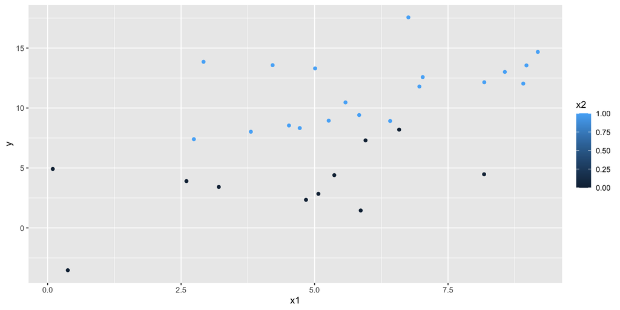

```r
legedata_pred2 |>
  ggplot() +
  aes(x = x1, y = y, color = x2) +
  geom_point()
```

## Forudsigelse af Y med lineær regression

**Kode**

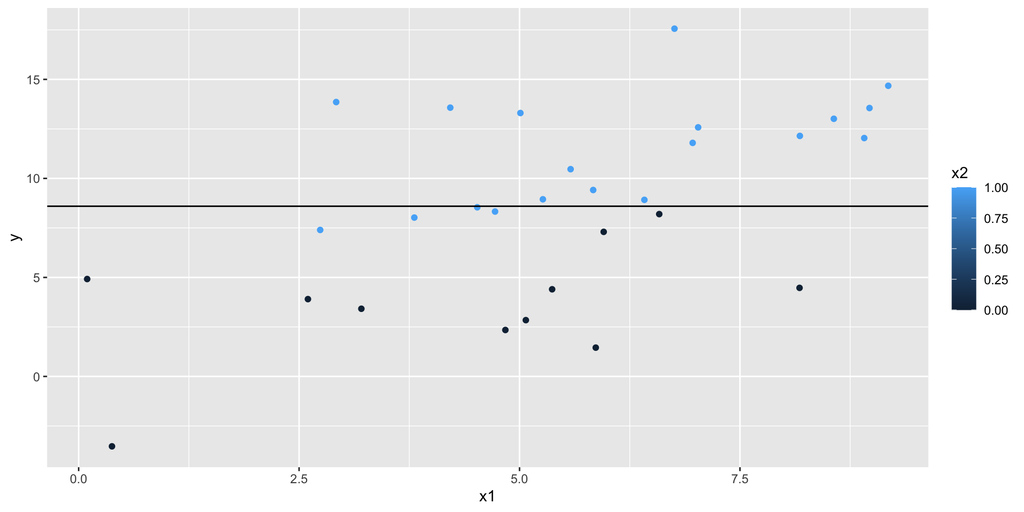

```r
legedata_pred2 |>
  ggplot() +
  aes(x = x1, y = y, color = x2) +
  geom_point() +
  geom_hline(aes(yintercept = y_forudsagt0))
```

## Forudsigelse af Y med lineær regression

**Kode**

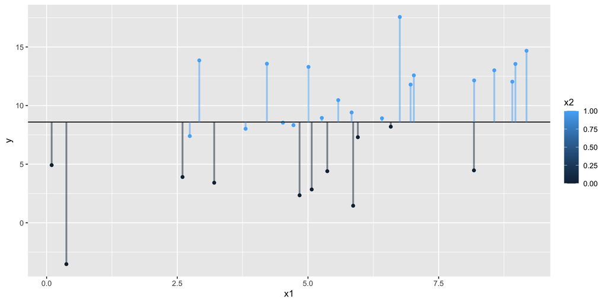

```r
legedata_pred2 |>
  ggplot() +
  aes(x = x1, y = y, color = x2) +
  geom_point() +
  geom_hline(aes(yintercept = y_forudsagt0)) +
  geom_linerange(aes(xmin = x1, xmax = x1, ymin = y_forudsagt0, ymax = y), alpha = .5, linewidth = 1)
```

## Forudsigelse af Y med lineær regression

**Kode**

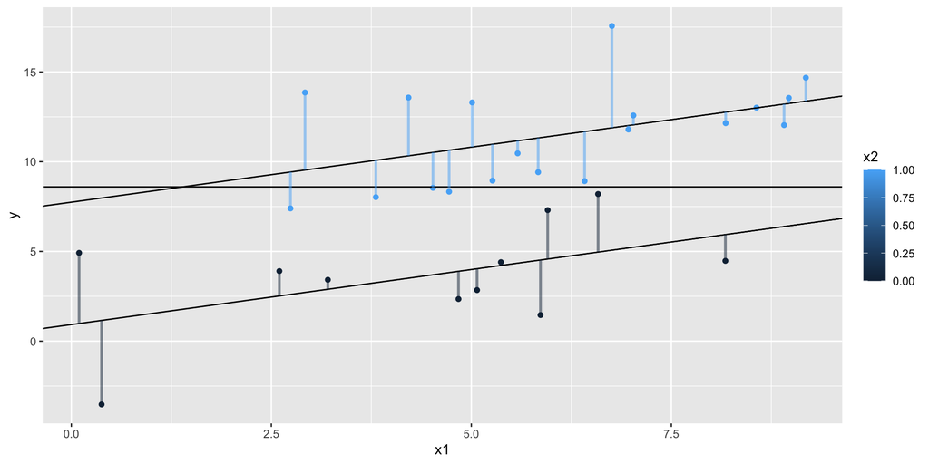

```r
legedata_pred2 |>
  ggplot() +
  aes(x = x1, y = y, color = x2) +
  geom_point() +
  geom_abline(slope = m$coefficients["x1"], intercept = m$coefficients["(Intercept)"]) +
  geom_abline(slope = m$coefficients["x1"], intercept = m$coefficients["(Intercept)"] + m$coefficients["x2"]) +
  geom_hline(aes(yintercept = y_forudsagt0)) +
  geom_linerange(aes(xmin = x1, xmax = x1, ymin = y_forudsagt, ymax = y), alpha = .5, linewidth = 1)
```

## Forudsigelse af Y med lineær regression

```r
# uforklaret varians (residualer^2)
sum(legedata_pred2$y_residual^2)
```

```
[1] 177.794
```

```r
# uforklaret varians i nulmodellen (residualer^2)
sum(legedata_pred2$y_residual0^2)
```

```
[1] 661.7172
```

```r
# hvor stor del af tidligere uforklaret varians er stadig uforklaret?
sum(legedata_pred2$y_residual^2) /
sum(legedata_pred2$y_residual0^2)
```

```
[1] 0.2686857
```

## Forudsigelse af Y med lineær regression

```r
# hvor stor del af tidligere uforklaret varians er stadig uforklaret?
sum(legedata_pred2$y_residual^2) /
sum(legedata_pred2$y_residual0^2)
```

```
[1] 0.2686857
```

```r
# hvor meget er så forklaret?
1 - (sum(legedata_pred2$y_residual^2) /
sum(legedata_pred2$y_residual0^2))
```

```
[1] 0.7313143
```

```r
summary(m0)$r.squared # R^2 i den univariate (nul)model
```

```
[1] 0
```

```r
summary(m)$r.squared  # R^2 i den store model
```

```
[1] 0.7313143
```

# Multipel regression

## Multipel regression

- Har kaldt det ‘*multivariat*’ regression
  - mere end to variable
- Den teknisk korrekte term er **multipel regression:**
  - et *Y*, flere *X*
- Reelt blot sofistikeret bivariat korrelation
  - partielle korrelationer:
  - den del af sammenhængen mellem X og Y,
  - som er uafhængig af Z
- Man fjerner den del af variansen i Y, som forklares af en tredjevariabel (Z),  
  inden man estimerer den ‘bivariate’ sammenhæng (X og Y)

## Multipel regression – og kausalitet

- Multipel lineær regression anvendes ofte til **kausal inferens**
  - mål: at identificere den direkte kausale påvirkning X har på Y
  - men ikke nødvendigvis!
- Fokus på et enkelt X (*treatment*) og et enkelt Y (*outcome*)
- Problemet: Når X og Y påvirkes af tredjevariable, kan vi ikke umiddelbart identificere den direkte (kausale) sammenhæng
- Men! Hvis vi kan observere og inkludere disse “kontrolvariable” i OLS-modellen, elimineres deres indflydelse på sammenhængen
- Så kan regressionskoefficienten $\beta_X$ få en kausal fortolkning (X påvirker Y)
- Kræver virkelig **godt overblik over teorien** (hvilke faktorer påvirker hvilke faktorer)
- Kræver **data for de problematiske tredjevariable** (at de kan måles, og vi har målt dem)

## Multipel regression – tredjevariable

- **Confounder** – vigtigst at forstå!
  - påvirker X eller sandsynligheden for X
  - påvirker Y
  - SKAL inkluderes som kontrolvariabel
  - ellers kan vi ikke fortolke sammenhængen X –> Y kausalt
  - fx: X = nyhedslæsning om Trump, Y = holdning til Trump, Z = uddannelsesniveau
- **Mediator**
  - påvirkes af X
  - påvirker Y
  - “mellemliggende” variabel
  - må IKKE inkluderes som kontrolvariabel

## Multipel regression – tredjevariable

- **Collider**
  - påvirkes af X
  - påvirkes af Y
  - må IKKE inkluderes som kontrolvariabel
- **Bagvedliggende årsager** og **uafhængige prediktorer**
  - påvirker X hhv. Y, men *ikke* den anden
  - gør ingen forskel for sammenhængen X –> Y, om de inkluderes som kontrolvariable
- **Kombinationer** – tricky

## Kausaldiagrammer

- Et virkelig nyttigt værktøj til at lære og kommunikere om kausal inferens
- Også til at designe forskning
- Variable tegnes med “punkter” (nodes)
  - X
  - Y
  - Z1
  - Z2
- Variablene forbindes med pile
- Alle pilene har en retning
  - X –> Y
- Illustrerer antagelser, problemer og løsninger i vores analyser

### Kausaldiagram: direkte sammenhæng

**Kode**

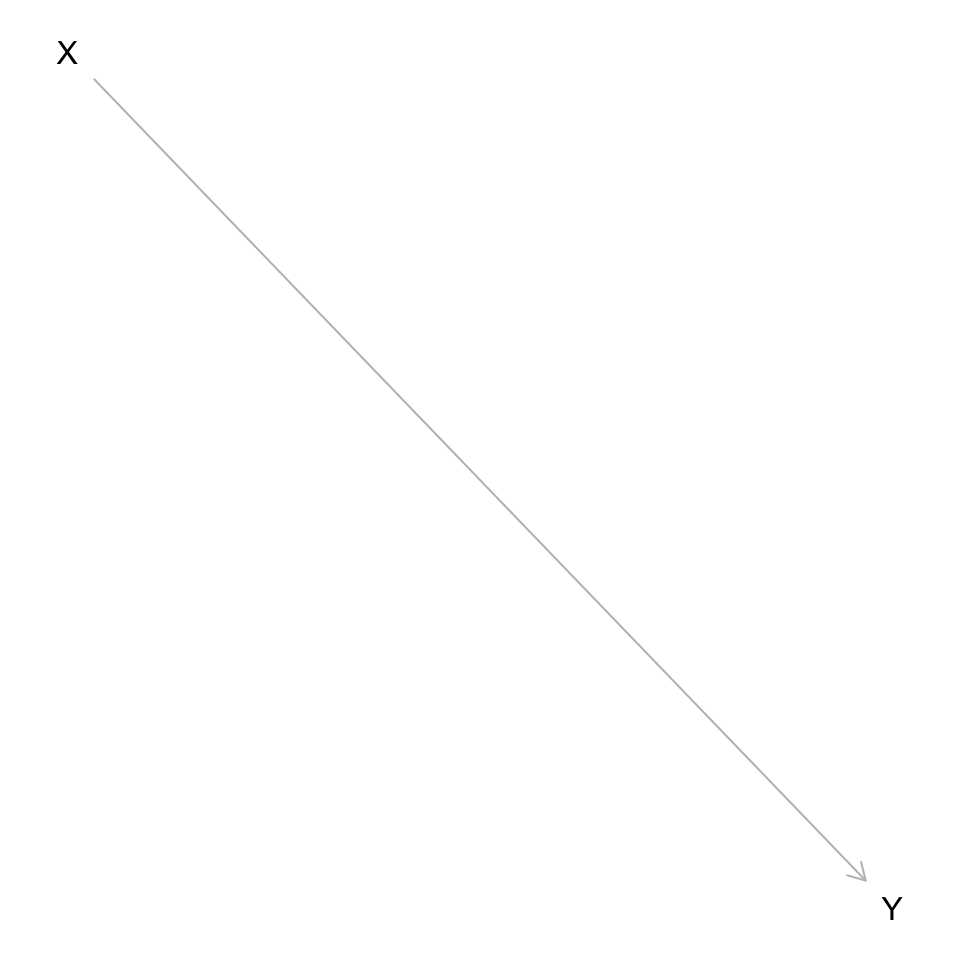

```r
library(dagitty)

dagitty("dag{
X -> Y
}") |> plot()
```

### Kausaldiagram: flere uafhængige prediktorer

**Kode**

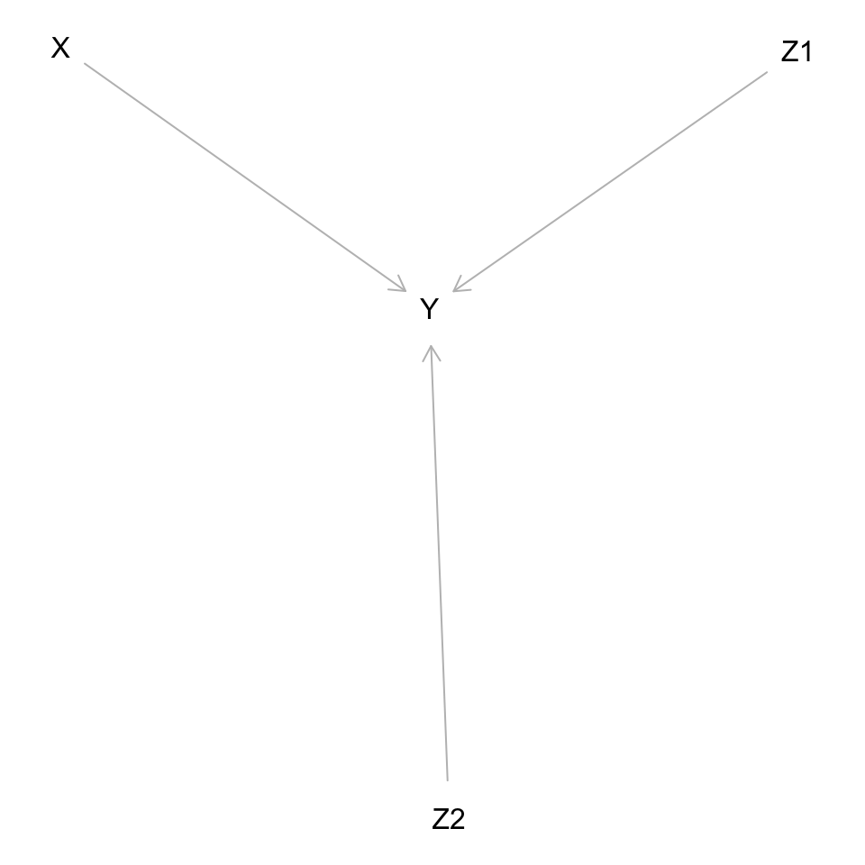

```r
library(dagitty)

dagitty("dag{
X -> Y
Z1 -> Y
Z2 -> Y
}") |> plot()
```

### Kausaldiagram: flere bagvedliggende årsager

**Kode**

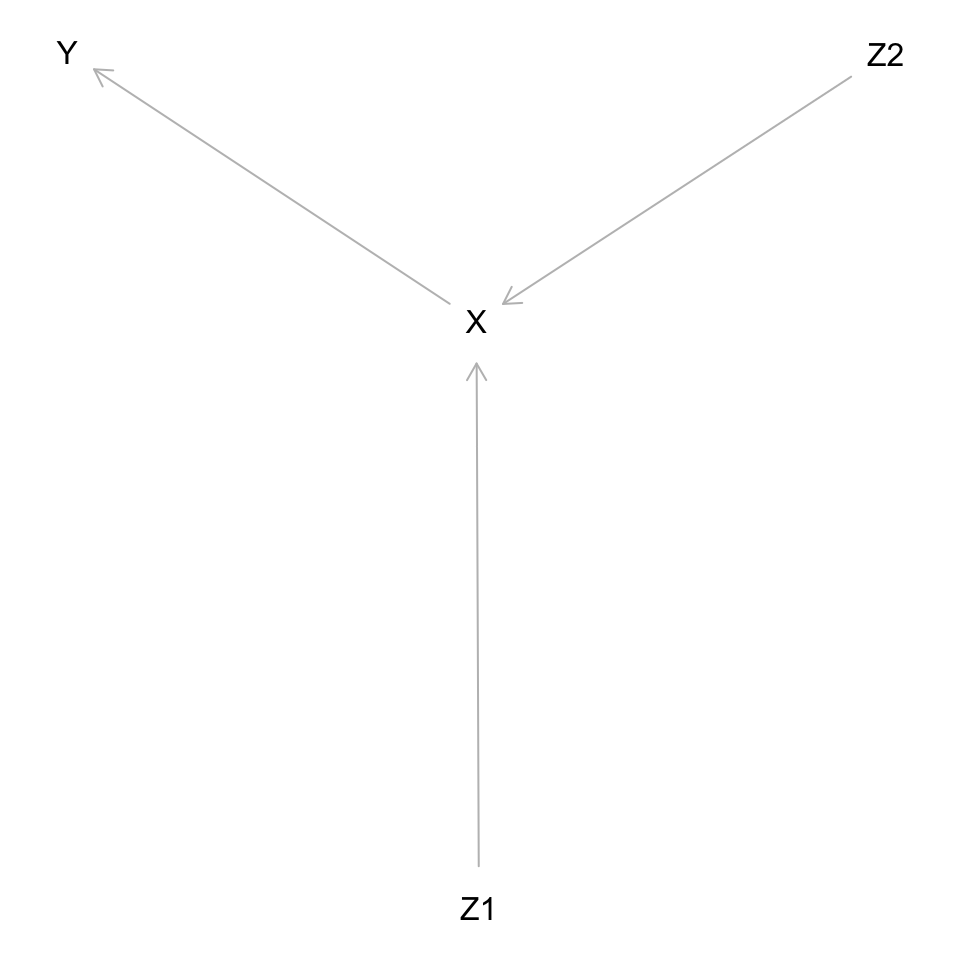

```r
library(dagitty)

dagitty("dag{
X -> Y
Z1 -> X
Z2 -> X
}") |> plot()
```

### Kausaldiagram: en confounder

**Kode**

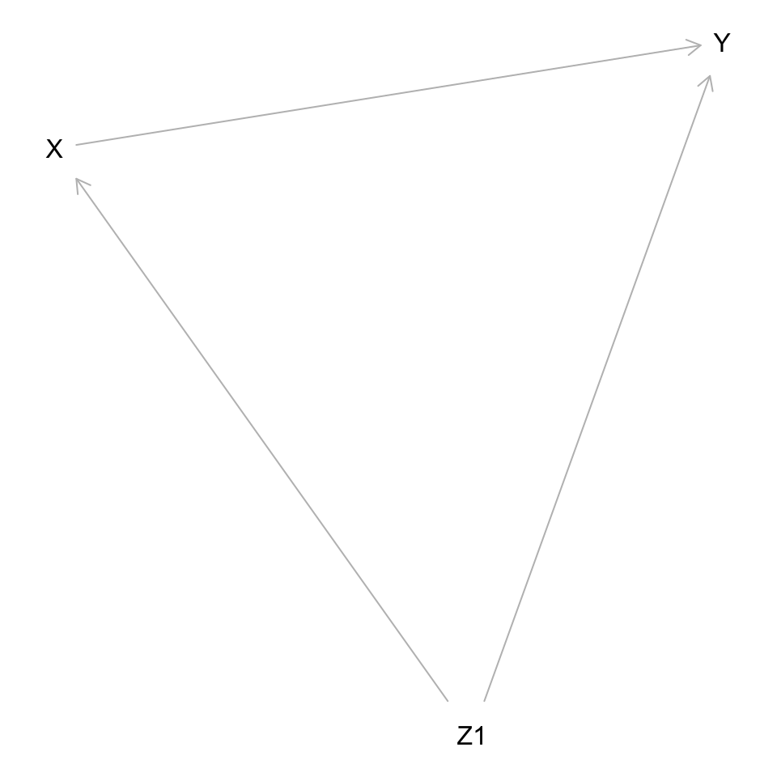

```r
dagitty("dag{
X -> Y
Z1 -> X
Z1 -> Y
}") |> plot()
```

### Kausaldiagram: to confounders

**Kode**

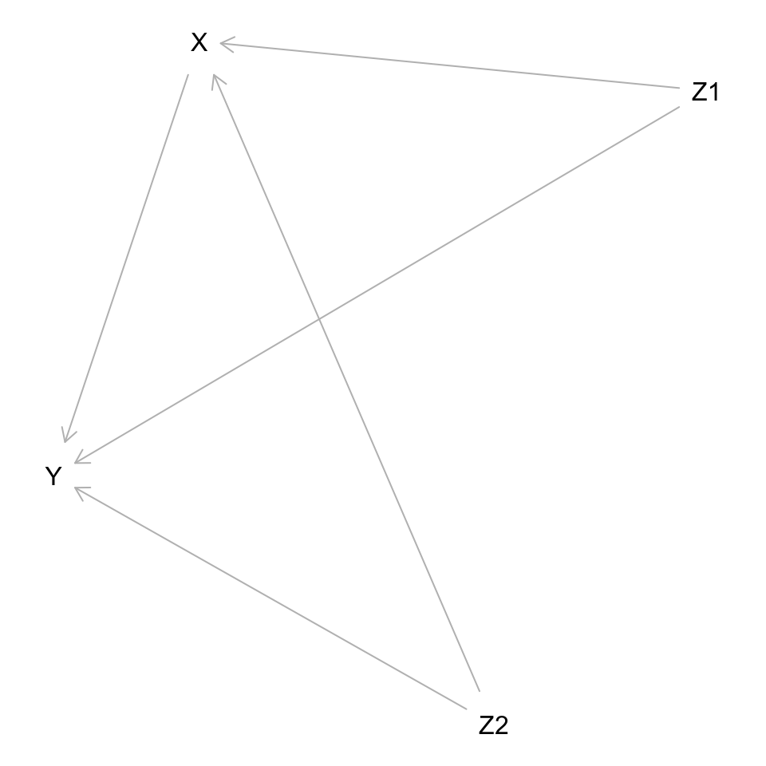

```r
dagitty("dag{
X -> Y
Z1 -> X
Z1 -> Y
Z2 -> X
Z2 -> Y
}") |> plot()
```

### Kausaldiagram: en mediator

**Kode**

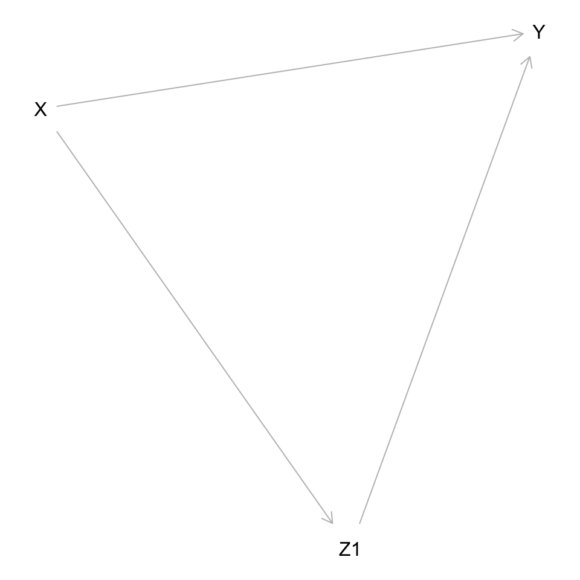

```r
dagitty("dag{
X -> Y
X -> Z1
Z1 -> Y
}") |> plot()
```

### Kausaldiagram: …

**Kode**

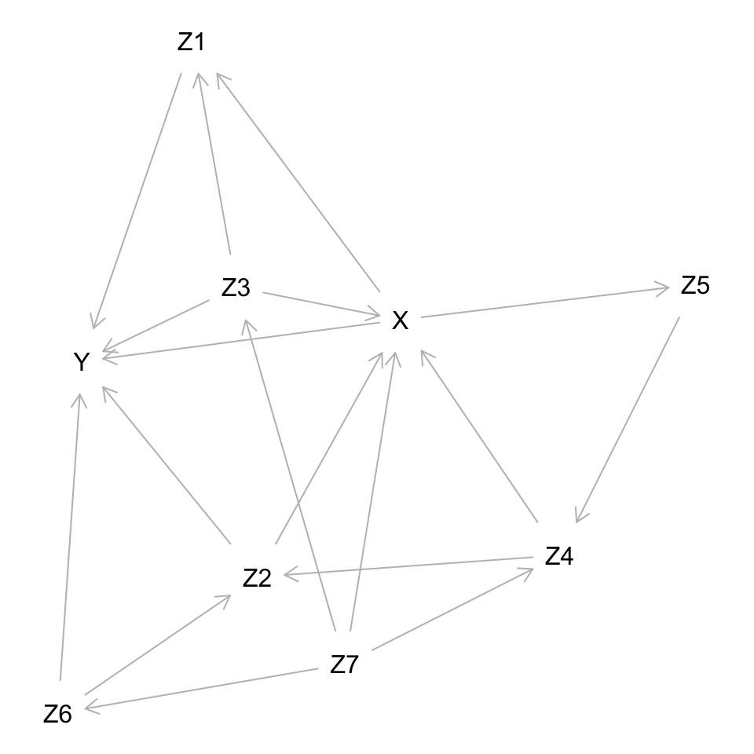

```r
dagitty("dag{
X -> Y
X -> Z1
Z1 -> Y
Z2 -> X
Z2 -> Y
Z3 -> Y
Z3 -> X
Z3 -> Z1
Z4 -> X
Z4 -> Z2
X -> Z5
Z5 -> Z4
Z6 -> Z2
Z6 -> Y
Z7 -> Z3
Z7 -> X
Z7 -> Z4
Z7 -> Z6
}") |> plot()
```

### Kausaldiagram: en confounder (igen)

- Vi glemmer lige alle de andre
- Denne er vigtigst for at forstå regression med kontrolvariable
- Eksempel:
  - X = venner med indvandrerbaggrund
  - Y = holdning til indvandring
  - Z1 = bor i en stor by
- Vi ser på et konkret eksempel (data) med en *binær confounder*

**Kode**

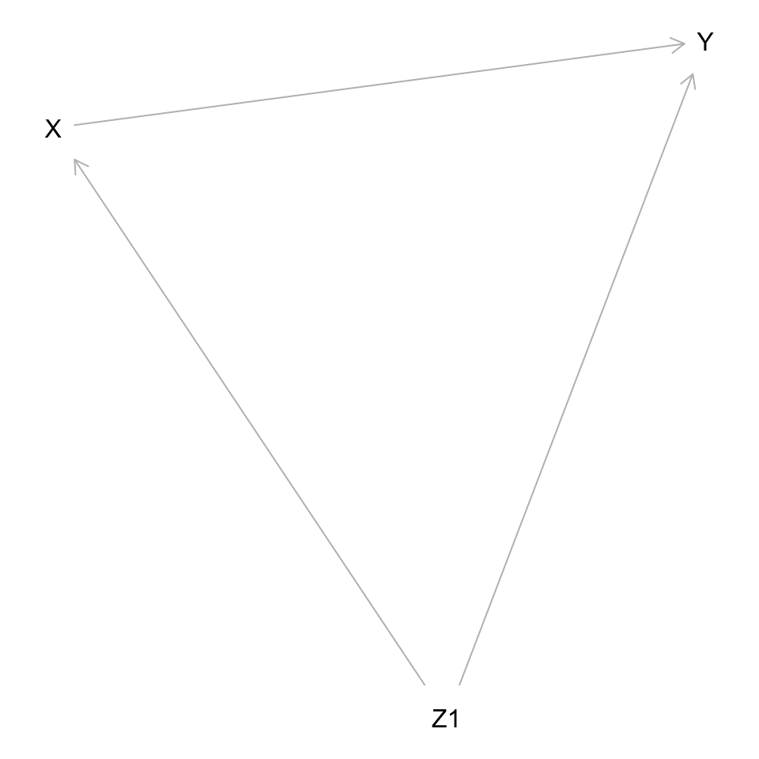

```r
dagitty("dag{
X -> Y
Z1 -> X
Z1 -> Y
}") |> plot()
```

## Simulerede data med en confounder

- Vi laver et datasæt med x1, x2 og y
- Vi vil identificere den direkte sammenhæng mellem x1 og y
  - → 2,5 (har vi bestemt)
- x2 påvirker både x1 og y → confounder!

**Kode**

```r
set.seed(3)

legedata_ny <- tibble(
  # binær confounder
  x2 = sample(c(0, 1), size = 500, replace = TRUE, prob = c(.25, .75)),
  # x1 påvirkes af x2
  x1 = 10 * x2 + rnorm(n = 500, mean = 5, sd = 2),
  # y påvirkes af både x1 og x2
  y = 2.5 * x1 + 50 * x2 + rnorm(500, sd = 5))

# vis data
kable(head(legedata_ny, 10), digits = 2)
```

## Simulerede data med en confounder

| x2 | x1 | y |
| --- | --- | --- |
| 1 | 13.93 | 80.97 |
| 0 | 7.74 | 12.65 |
| 1 | 15.28 | 90.25 |
| 1 | 13.43 | 84.62 |
| 1 | 18.76 | 95.79 |
| 1 | 16.11 | 82.74 |
| 1 | 11.31 | 79.47 |
| 1 | 13.90 | 82.55 |
| 1 | 14.95 | 92.80 |
| 1 | 10.68 | 78.14 |

## OLS-model uden kontrol for x2

**Kode**

```r
lm(y ~ x1, data = legedata_ny) |>
  summary()
```

```
Call:
lm(formula = y ~ x1, data = legedata_ny)

Residuals:
    Min      1Q  Median      3Q     Max
-41.445  -7.262   0.575   6.973  33.183

Coefficients:
             Estimate Std. Error t value            Pr(>|t|)
(Intercept) -13.64173    1.26865  -10.75 <0.0000000000000002 ***
x1            6.59278    0.09578   68.83 <0.0000000000000002 ***
---
Signif. codes:  0 '***' 0.001 '**' 0.01 '*' 0.05 '.' 0.1 ' ' 1

Residual standard error: 10.52 on 498 degrees of freedom
Multiple R-squared:  0.9049,    Adjusted R-squared:  0.9047
F-statistic:  4738 on 1 and 498 DF,  p-value: < 0.00000000000000022
```

## OLS-model uden kontrol for x2

- Når vi *ikke* kontrollerer for alle confounders, er den estimerede sammenhæng *biased*
  - *omitted variable bias*
  - kan potentielt være helt off
  - vanskeligt at fortolke
  - et gradsspørgsmål
  - afhænger af confounderens *styrke*:
    - x2 –> x1
    - x2 –> y

## OLS-model *med* kontrol for x2

**Kode**

```r
lm(y ~ x1 + x2, data = legedata_ny) |>
  summary()
```

```
Call:
lm(formula = y ~ x1 + x2, data = legedata_ny)

Residuals:
     Min       1Q   Median       3Q      Max
-15.6330  -3.5530   0.1488   3.2397  12.4629

Coefficients:
            Estimate Std. Error t value            Pr(>|t|)
(Intercept)   0.3397     0.6827   0.498               0.619
x1            2.3738     0.1102  21.550 <0.0000000000000002 ***
x2           51.5139     1.2277  41.958 <0.0000000000000002 ***
---
Signif. codes:  0 '***' 0.001 '**' 0.01 '*' 0.05 '.' 0.1 ' ' 1

Residual standard error: 4.942 on 497 degrees of freedom
Multiple R-squared:  0.9791,    Adjusted R-squared:  0.979
F-statistic: 1.162e+04 on 2 and 497 DF,  p-value: < 0.00000000000000022
```

- Når vi kan kontrollere for alle confounders, kan vi grave den sande, kausale sammenhæng frem: → ca. 2,5

## Grafisk illustration

- Plotter sammenhængen mellem *x1* og *y*
  - *biased* lineær tendenslinje

**Kode**

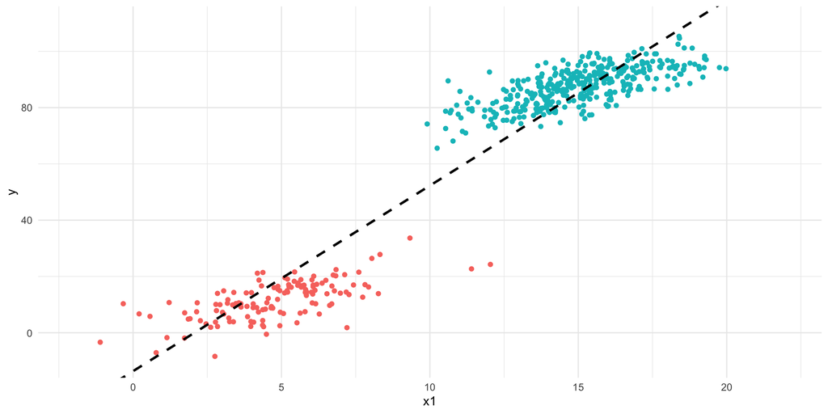

```r
p1 <- legedata_ny |>
  ggplot() +
  aes(x = x1, y = y) +
  geom_point(aes(color = factor(x2))) +
  geom_smooth(aes(x = x1, y = y), method = "lm", se = FALSE, color = "black", linetype = "dashed") +
  guides(color = "none") +
  coord_cartesian(xlim = c(-2, 22), ylim = c(-10, 110)) +
  theme_minimal()

p1
```

## Grafisk illustration

1. Regresser *x1* på *x2* (confounder)
2. Beholder kun resterende uforklaret varians → *x1_rest*
3. Plotter sammenhængen mellem *x1_rest* og *y*

**Kode**

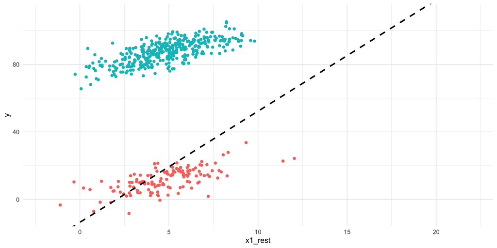

```r
# predict x1 med x2
m_x1 <- lm(x1 ~ x2, data = legedata_ny)

# gemmer "resten" i ny variabel: y_rest
legedata_ny_kontrol <- legedata_ny |>
  mutate(x1_rest = resid(m_x1) +
           m_x1$coefficients[1])

p2 <- legedata_ny_kontrol |>
  ggplot() +
  aes(x = x1_rest, y = y) +
  geom_point(aes(color = factor(x2))) +
  geom_smooth(aes(x = x1, y = y),
              method = "lm", se = FALSE,
              color = "black", linetype = "dashed") +
  guides(color = "none") +
  coord_cartesian(xlim = c(-2, 22),
                  ylim = c(-10, 110)) +
  theme_minimal()

p2
```

## Grafisk illustration

1. Regresser *y* på *x2* (confounder)
2. Beholder kun resterende uforklaret varians → *y_rest*
3. Plotter sammenhængen mellem *x1_rest* og *y_rest*

**Kode**

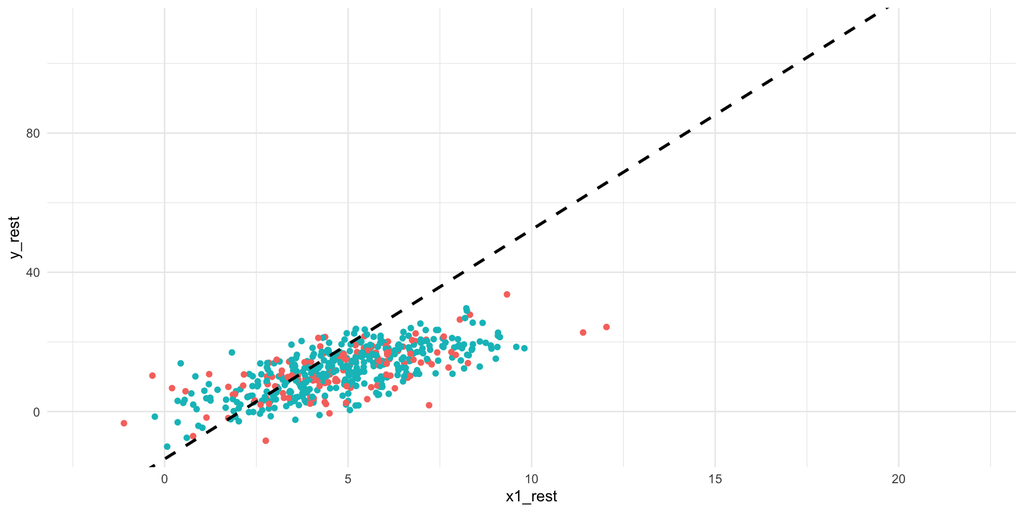

```r
# predict y med x2
m_y <- lm(y ~ x2, data = legedata_ny)

# gemmer "resten" i ny variabel: y_rest
legedata_ny_kontrol <- legedata_ny_kontrol |>
  mutate(y_rest = resid(m_y) +
           m_y$coefficients[1])

p3 <- legedata_ny_kontrol |>
  ggplot() +
  aes(x = x1_rest, y = y_rest) +
  geom_point(aes(color = factor(x2))) +
  geom_smooth(aes(x = x1, y = y),
              method = "lm", se = FALSE,
              color = "black", linetype = "dashed") +
  guides(color = "none") +
  coord_cartesian(xlim = c(-2, 22),
                  ylim = c(-10, 110)) +
  theme_minimal()

p3
```

## Grafisk illustration

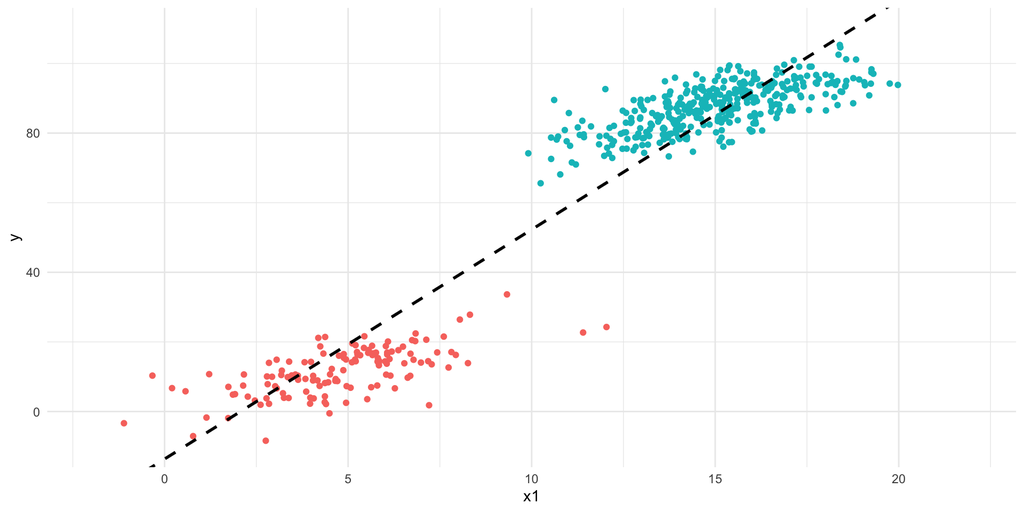

## Grafisk illustration

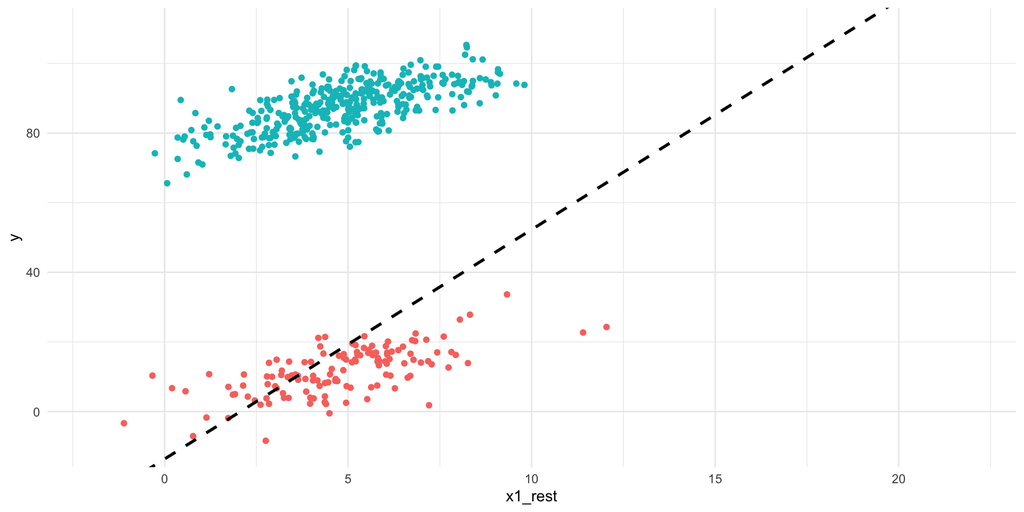

## Grafisk illustration

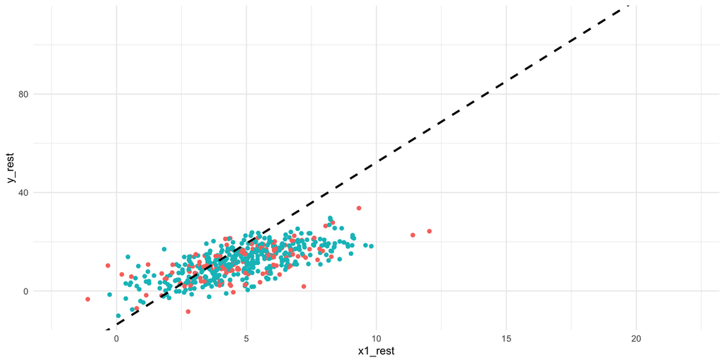

## Grafisk illustration

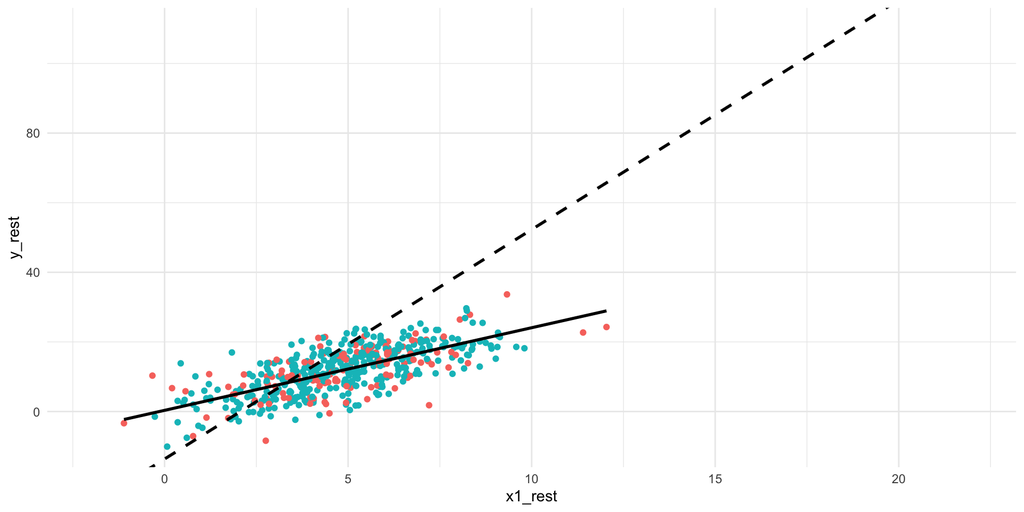

## Multipel regression – og kausalitet

- Man kan godt lave **kausal inferens** med regression
  - kontrollér for alle confounders,der påvirker X og Y
  - OLS eliminerer confoundernes indflydelse ved at fjerne den varians i X og Y, de er skyld i
- **Udfordringen:**
  - der kan være confounders, vi ikke har målt
  - der kan altid være flere confounders, vi end ikke kender
  - kausaldiagrammet kan være komplekst
  - kausaldiagrammet (vores teori) kan være forkert
  - forkerte kontrolvariable kan introducere nye problemer med confounding

## Multipel regression – og kausalitet

- Derfor er kausal inferens med kontrolvariable uperfekt og afhængigt af teori og argumentation
- Som udgangspunkt fortolker vi *ikke* vores regressionskoefficient kausalt
  - men vi kan ydmygt nærme os
- OLS kan anvendes med særlige forskningsdesigns, der er skabt til at identificere kausale effekter
  - fx eksperimenter

# Vigtige noter om OLS

1. Præsentation af regressionstabeller
2. Manglende værdier
3. Antagelserne bag OLS-regression
4. Udvidelser til OLS-regression

## Note om præsentation af regressionstabeller

- Efter vi har kørt og gemt en model med `m <- lm(y ~ x, data)`, kan vi fx se på resultaterne med:
  1. `summary(m)`
  2. `broom::tidy(m)`
  3. `modelsummary::modelsummary(m)`
  4. `stargazer::stargazer(m)`
- c og d kan også bruges til at gemme en regressionstabel udenfor R samt tilpasse layoutet
- c kan bruges sammen med andre “tabelpakker” i R, fx {kable} og {kableExtra}
  - https://modelsummary.com/vignettes/modelsummary.html

## Note om præsentation af regressionstabeller

Sørg for altid tydeligt at præsentere:

1. Alle **regressionskoefficienter** samt en indikation på deres statistiske signifikans (standardfejl, p-værdier, *** eller en kombi)
   - man kan evt. udelade koefficienter for nogle kontrolvariable, men så skal det gøres tydeligt
   - hvilke signifikansniveauer refererer *, **, *** til?
2. Hvad de(n) **afhængige variable** er
3. Hvad de(n) **uafhængige variable** er (inkl. referencekategorier)
4. **Antallet af enheder** i modellen (*n*)
   - gerne en note om datakilden/-sættet samt hvad enhederne er
5. Typen af regressionsmodel (OLS)
6. Evt. **statistikker** til beskrivelse af modellen (fx $R^2$)

## Note om præsentation af regressionstabeller

**Kode**

```r
m1 <- lm(y ~ x1, data = legedata_ny)
m2 <- lm(y ~ x1 + x2, data = legedata_ny)

regtabel <- modelsummary(
  # vælg og navngiv modeller (liste)
  models = list("Bivariat model (y)" = m1, "Multipel model (y)" = m2),
  # vælg output (eventuelt filnavn)
  output = "kableExtra",
  # titel
  title = "OLS-modeller med simulerede data",
  # regressionskoefficienter med signifikansstjerner?
  estimate = "{estimate}{stars}",
  # omdøb koefficient-navne
  coef_rename = c("(Intercept)" = "Konstant", "x2" = "x2 (ref. = 0)"),
  # vælg statistikker, formater label og tal
  gof_map = tibble::tribble(~raw,        ~clean,          ~fmt,
                            "nobs",      "N",             0,
                            "r.squared", "R<sup>2</sup>", 2),

  # tilpasninger fra kableExtra-pakken

  # antal decimaler
  fmt = 2) |>

  # skriftstørrelse (kableExtra)
  kable_styling(font_size = 24) |>

  # signifikansniveauer i fodnoten
  footnote(general = "OLS-regression. Standardfejl i parantes. *p < 0.05, **p < 0.01, ***p < 0.001. Simulerede data.")

regtabel
```

## Note om præsentation af regressionstabeller

OLS-modeller med simulerede data

|  | Bivariat model (y) | Multipel model (y) |
| --- | --- | --- |
| Konstant | −13.64*** | 0.34 |
|  | (1.27) | (0.68) |
| x1 | 6.59*** | 2.37*** |
|  | (0.10) | (0.11) |
| x2 (ref. = 0) |  | 51.51*** |
|  |  | (1.23) |
| N | 500 | 500 |
| R<sup>2</sup> | 0.90 | 0.98 |

Note:  
OLS-regression. Standardfejl i parantes. *p < 0.05, **p < 0.01, ***p < 0.001. Simulerede data.

## Note om præsentation af regressionstabeller

- Skift evt. ‘*output = “regtabel.html”*’ ud med
  - *’output = “regtabel.txt”*’
  - ‘*output = “regtabel.docx”*’
  - etc.
- Man kan også manuelt lave en tabel og indsætte værdierne i MS Word

**Kode**

```r
modelsummary(
  models = list("Bivariat model (1)" = m1, "Multipel model (2)" = m2),
  # vælg output (eventuelt filnavn)
  output = "regtabel.html", # "regtabel.docx", "regtabel.txt" etc.
  # titel
  title = "OLS-modeller med simulerede data",
  # regressionskoefficienter med signifikansstjerner?
  estimate = "{estimate}{stars}",
  # omdøb koefficient-navne
  coef_rename = c("(Intercept)" = "Konstant"),
  # vælg statistikker, formater label og tal
  gof_map = tibble::tribble(~raw,        ~clean,          ~fmt,
                            "nobs",      "N",             0,
                            "r.squared", "R<sup>2</sup>", 2))
```

## Note om manglende værdier

- `lm()` inkluderer alle de enheder, som har *komplette observationer* på alle de variable, både *Y* og *X*, som indgår i modellen
- Udelader/bortkaster dermed alle de enheder, som har en eller flere manglende værdier (*NAs*)
- **Eksempel** med varierende antal manglende værdier &narr;

**Kode**

```r
# 1 stk. missing y (række 1)
legedata_missing1 <- legedata |>
  mutate(y = ifelse(row_number() == 1, NA, y))

# + 1 stk. missing x1, x2, y (række 7)
legedata_missing2 <- legedata_missing1 |>
  mutate(across(c(x1, x2, y), ~ifelse(row_number() == 7, NA, .)))

# + 1 stk. missing x1 (række 3) + 1 stk. missing x2 (række 5)
legedata_missing3 <- legedata_missing2 |>
  mutate(x1 = ifelse(row_number() == 3, NA, x1),
         x2 = ifelse(row_number() == 5, NA, x2))

kable(head(legedata_missing3, 10))
```

## Note om manglende værdier

| x1 | x2 | x3 | y |
| --- | --- | --- | --- |
| 3.206171 | 0 | A | NA |
| 5.369698 | 0 | B | 4.400941 |
| NA | 0 | B | 4.472546 |
| 2.739249 | 1 | B | 7.397413 |
| 4.839497 | NA | B | 2.345731 |
| 5.264841 | 1 | B | 8.944845 |
| NA | NA | B | NA |
| 4.520604 | 1 | B | 8.541311 |
| 8.968948 | 1 | B | 13.553128 |
| 4.722426 | 1 | B | 8.326939 |

## Note om manglende værdier

**Kode**

```r
# kør model med forskellige datasæt (varierende antal NAs)
m0 <- lm(y ~ x1 + x2, data = legedata)
m1 <- lm(y ~ x1 + x2, data = legedata_missing1)
m2 <- lm(y ~ x1 + x2, data = legedata_missing2)
m3 <- lm(y ~ x1 + x2, data = legedata_missing3)

# vis resultat
modelsummary(models = list(m0, m1, m2, m3),
             gof_omit = "AIC|BIC|Log.Lik|F|RMSE",
             fmt = 2,
             stars = TRUE)
```

## Note om manglende værdier

|  | Model 1 | Model 2 | Model 3 | Model 4 |
| --- | --- | --- | --- | --- |
| (Intercept) | 0.92 | 0.85 | 0.82 | 0.95 |
|  | (1.23) | (1.30) | (1.29) | (1.35) |
| x1 | 0.61** | 0.62** | 0.63** | 0.69** |
|  | (0.22) | (0.22) | (0.22) | (0.24) |
| x2 | 6.82*** | 6.86*** | 7.01*** | 6.51*** |
|  | (1.04) | (1.08) | (1.08) | (1.24) |
| Num.Obs. | 30 | 29 | 28 | 26 |
| R2 | 0.731 | 0.720 | 0.733 | 0.713 |
| R2 Adj. | 0.711 | 0.699 | 0.711 | 0.688 |

## Note om antagelserne bag OLS-regression<sup>1</sup>

1. **Validitet (vigtigt).** Gode *variable* (operationalisering), godt *sample* (repræsentativitet) og god *model* (ingen væsentlige udeladte variable)
2. **Linearitet og additivitet.** Sammenhængen mellem hvert X og Y er tilnærmelsesvist lineær og hvert led ($\beta * X$) lægger blot noget til $\hat{Y}$
3. **Uafhængige residualer.** Enheder, der ligner hinanden, tenderer ikke mod at have ens residualer (de er uafhængige)
4. **Ens varians af residualer (mindre vigtigt).** Ingen *systematisk* variation i, hvor rigtigt eller forkert modellen gætter
5. **Normalfordelte residualer (ikke vigtigt).** Residualerne – afvigelserne fra prediktionslinjen – følger en normalfordeling
[^3]: *Gelman & Hill (2007), “Data Analysis Using Regression and Multilevel/Hierarchical Models”, s. 45-47*

## Note om antagelserne bag OLS-regression<sup>1</sup>

Dertil kommer yderligere antagelser, hvis vi vil kunne sige, at en sammenhæng er **kausal**:

6. **Selection on observables (vigtigst).**
   - “tildeling” af værdier på X (treatment) afhænger måske af andre faktorer
   - men det er alene faktorer, som vi har observeret og inkluderet i vores model som kontrolvariable
7. …
[^4]: *Gelman & Hill (2007), “Data Analysis Using Regression and Multilevel/Hierarchical Models”, s. 45-47*

## Note om udvidelser til OLS-regression

Der skal kun mindre tilpasninger til for at kunne analysere:

1. Binære outcome-variable (logistisk regression)
2. Kategoriske outcome-variable (multinominel logistisk regression)
3. Ikke-lineære sammenhænge mellem X og Y (transformationer af X)
4. Interaktioner mellem X1 og X2 (effekten af X1 er betinget af X2)
5. Tidsserier (gentagne observationer)
6. Data fra mange forskellige forskningsdesigns

# Eksempel fra den virkelige verden (Valgundersøgelsen)

## Eksempel fra den virkelige verden (Valgundersøgelsen)

> Hvordan påvirker indkomst (1 lav - 15 høj) opbakning til højere beskatning af “høje indtægter” (1 lav - 5 høj)

**Kode**

```r
vu_select <- vu |>
  transmute(
    # holdning til beskatning af høje indtægter
    hojere_beskatning = scales::rescale(as.double(Q47_1), to = c(5, 1)),
    # indkomst
    indkomst = Q78,
    # ideologi
    venstre_hojre = Q64_0,
    # uddannelse
    uddannelse = udd,
    # alder
    alder = alder_på_valgdag,
    # køn
    mand = case_when(gender == 1 ~ 1,
                     gender == 2 ~ 0,
                     .default = NA))

modelsummary::datasummary_skim(vu_select)
```

## Eksempel fra den virkelige verden (Valgundersøgelsen)

|  | Unique (#) | Missing (%) | Mean | SD | Min | Median | Max |  |
| --- | --- | --- | --- | --- | --- | --- | --- | --- |
| hojere_beskatning | 6 | 7 | 3.0 | 1.4 | 1.0 | 3.0 | 5.0 |  |
| indkomst | 16 | 7 | 6.3 | 3.6 | 1.0 | 6.0 | 15.0 |  |
| venstre_hojre | 12 | 16 | 5.0 | 2.8 | 0.0 | 5.0 | 10.0 |  |
| uddannelse | 6 | 0 | 3.6 | 1.7 | 1.0 | 3.0 | 6.0 |  |
| alder | 74 | 0 | 52.9 | 18.5 | 18.0 | 55.0 | 90.0 |  |
| mand | 3 | 0 | 0.5 | 0.5 | 0.0 | 0.0 | 1.0 |  |

## Eksempel fra den virkelige verden (Valgundersøgelsen) – kausaldiagram

> Fokus: indkomst (X) → hojere_beskatning (Y)

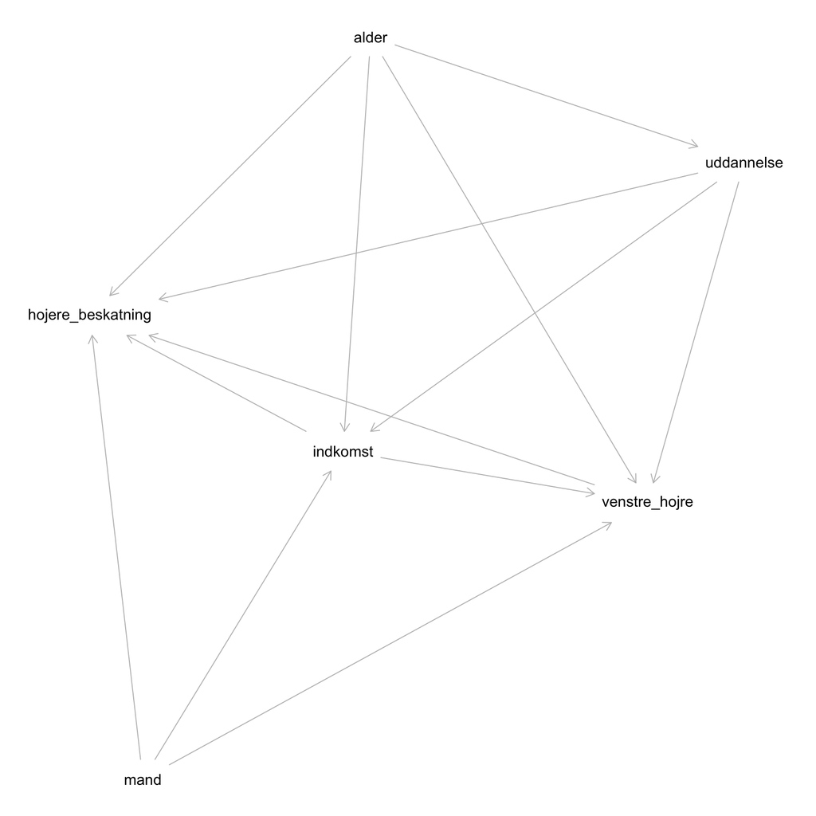

## Eksempel fra den virkelige verden (Valgundersøgelsen) – regressionsmodeller

> **Confounders:** *alder*, *køn* og *uddannelse*

**Kode**

```r
m1 <- lm(hojere_beskatning ~ indkomst, data = vu_select)
m2 <- lm(hojere_beskatning ~ indkomst + mand, data = vu_select)
m3 <- lm(hojere_beskatning ~ indkomst + alder, data = vu_select)
m4 <- lm(hojere_beskatning ~ indkomst + uddannelse, data = vu_select)
m5 <- lm(hojere_beskatning ~ indkomst + mand + alder + uddannelse, data = vu_select)
```

**Kode**

```r
modelsummary(
  # vælg og navngiv modeller (liste)
  models = list(m1, m2, m3, m4, m5),
  # vælg output (eventuelt filnavn)
  output = "kableExtra",
  # titel
  title = "Sammenhængen mellem indkomst og ønske om højere topskat",
  # regressionskoefficienter med signifikansstjerner?
  estimate = "{estimate}{stars}",
  # omdøb koefficient-navne
  coef_rename = c("(Intercept)" = "Konstant"),
  # vælg statistikker, formater label og tal
  gof_map = tibble::tribble(~raw,        ~clean,          ~fmt,
                            "nobs",      "N",             0,
                            "r.squared", "R<sup>2</sup>", 2),

  # tilpasninger fra kableExtra-pakken

  # antal decimaler
  fmt = 2) |>

  # skriftstørrelse (kableExtra)
  kable_styling(font_size = 24) |>

  # signifikansniveauer i fodnoten
  footnote(general = "*p < 0.05, **p < 0.01, ***p < 0.001. Data: Valgundersøgelsen 2022.")
```

Sammenhængen mellem indkomst og ønske om højere topskat

|  | Model 1 | Model 2 | Model 3 | Model 4 | Model 5 |
| --- | --- | --- | --- | --- | --- |
| Konstant | 3.53*** | 3.51*** | 2.98*** | 3.38*** | 2.83*** |
|  | (0.05) | (0.06) | (0.10) | (0.07) | (0.10) |
| indkomst | −0.09*** | −0.09*** | −0.09*** | −0.10*** | −0.10*** |
|  | (0.01) | (0.01) | (0.01) | (0.01) | (0.01) |
| mand |  | 0.03 |  |  | 0.02 |
|  |  | (0.05) |  |  | (0.05) |
| alder |  |  | 0.01*** |  | 0.01*** |
|  |  |  | (0.00) |  | (0.00) |
| uddannelse |  |  |  | 0.06*** | 0.06** |
|  |  |  |  | (0.02) | (0.02) |
| N | 2470 | 2459 | 2464 | 2470 | 2453 |
| R<sup>2</sup> | 0.05 | 0.05 | 0.07 | 0.06 | 0.08 |

Note:  
*p < 0.05, **p < 0.01, ***p < 0.001. Data: Valgundersøgelsen 2022.

## Opsummering

- **Lineær regression** bruges til både bivariat og ‘*multivariat*’ sammenhængsanalyse
  - også *prediktion* (OLS-modeller estimeres ved at minimere prediktionsfejl)
- **Multipel regression** *kan* (behøver ikke) anvendes til *kausal inferens*
  - kræver (1) godt overblik over teori, (2) gode data, (3) stærke antagelser
- Identificer **confounders** (evt. med kausaldiagram):
  - påvirker X og Y (påvirkes ikke af X eller Y)
- Inkludér confounders i OLS-modellen for at justere estimatet af *X-Y*-sammenhængen
- Generelt: begynd med at antage *ikke-kausal sammenhæng* (korrelation)
  - så kan vi ydmygt nærme os kausalitet – med tydelige antagelser og forbehold
- Med mindre OLS bruges sammen med mere avancerede forskningsdesigns
  - guldstandarden: **eksperimenter** → næste gang

## Næste uge

- **Eksperimenter**
- Lidt mere kausalitet / kausal inferens